# Исследование продаж компьютерных игр

Интернет-магазин компьютерных игр с продажами по всему миру в декабре 2016 года планирует кампанию продаж на 2017 год. Для более точного планирования продаж и рекламных кампаний ему необходимо исследование факторов, влияющих на успешность продаж игр.

**Задача:** Выявить закономерности и характеристики, влияющие на успешность продаж игр.

**Описание данных**

Из открытых источников доступны исторические данные до 2016 года о продажах игр (миллионы проданных копий в разных частях мира), оценки пользователей и экспертов, жанры и платформы игр, рейтинг от организации ESRB (Entertainment Software Rating Board).  
Данные за 2016 год могут быть неполными.

**Ход исследования**

1. Обзор данных.
2. Предобработка данных.
3. Исследовательский анализ данных.
4. Портрет пользователя каждого региона.
5. Проверка гипотез.
6. Общий вывод.

```python
# import librarie
import os
import warnings
warnings.filterwarnings('ignore')

import matplotlib.pyplot as plt
import pandas as pd
import seaborn as sns

from scipy import stats as st
```

```python
# display settings
pd.options.display.max_columns = None
pd.set_option('display.max_colwidth', 100)
pd.set_option("display.precision", 4)

sns.set_style("darkgrid")

%matplotlib inline
```

## Обзор и предобработка данных

```python
# data path
path = os.path.join(os.path.dirname(os.getcwd()), '5_Project1')
```

```python
# define function to read files and display information about the data
def data_overview(filename, path):
    """ Функция принимает строку - название файла с данными и
    путь к файлу с данными.
    Читает данные, выводит основную информацию,
    проверяет на наличие явных дубликатов и пропусков.
    Возвращает датафрейм."""

    # reading file
    try:
        df = pd.read_csv(os.path.join(path, filename))
    except:
        df = pd.read_csv('/datasets/games.csv')

    # get first and last 5 rows
    display(df)

    # get information about the data
    print()
    print(df.info())

    # check for duplicates
    print()
    if df.duplicated().sum() > 0:
        print('В данных есть явные дубликаты')
    else:
        print('В данных нет явных дубликатов')

    # check for NaN
    print()
    if df.isna().sum().sum() > 0:
        print('В данных есть пропущенные значения')
    else:
        print('В данных нет пропущенных значений')

    return df
```

```python
# data overview
data = data_overview('games.csv', path)
```

|  | Name | Platform | Year_of_Release | Genre | NA_sales | EU_sales | JP_sales | Other_sales | Critic_Score | User_Score | Rating |
| --- | --- | --- | --- | --- | --- | --- | --- | --- | --- | --- | --- |
| 0 | Wii Sports | Wii | 2006.0 | Sports | 41.36 | 28.96 | 3.77 | 8.45 | 76.0 | 8 | E |
| 1 | Super Mario Bros. | NES | 1985.0 | Platform | 29.08 | 3.58 | 6.81 | 0.77 | NaN | NaN | NaN |
| 2 | Mario Kart Wii | Wii | 2008.0 | Racing | 15.68 | 12.76 | 3.79 | 3.29 | 82.0 | 8.3 | E |
| 3 | Wii Sports Resort | Wii | 2009.0 | Sports | 15.61 | 10.93 | 3.28 | 2.95 | 80.0 | 8 | E |
| 4 | Pokemon Red/Pokemon Blue | GB | 1996.0 | Role-Playing | 11.27 | 8.89 | 10.22 | 1.00 | NaN | NaN | NaN |
| ... | ... | ... | ... | ... | ... | ... | ... | ... | ... | ... | ... |
| 16710 | Samurai Warriors: Sanada Maru | PS3 | 2016.0 | Action | 0.00 | 0.00 | 0.01 | 0.00 | NaN | NaN | NaN |
| 16711 | LMA Manager 2007 | X360 | 2006.0 | Sports | 0.00 | 0.01 | 0.00 | 0.00 | NaN | NaN | NaN |
| 16712 | Haitaka no Psychedelica | PSV | 2016.0 | Adventure | 0.00 | 0.00 | 0.01 | 0.00 | NaN | NaN | NaN |
| 16713 | Spirits & Spells | GBA | 2003.0 | Platform | 0.01 | 0.00 | 0.00 | 0.00 | NaN | NaN | NaN |
| 16714 | Winning Post 8 2016 | PSV | 2016.0 | Simulation | 0.00 | 0.00 | 0.01 | 0.00 | NaN | NaN | NaN |

16715 rows × 11 columns

```
<class 'pandas.core.frame.DataFrame'>
RangeIndex: 16715 entries, 0 to 16714
Data columns (total 11 columns):
 #   Column           Non-Null Count  Dtype
---  ------           --------------  -----
 0   Name             16713 non-null  object
 1   Platform         16715 non-null  object
 2   Year_of_Release  16446 non-null  float64
 3   Genre            16713 non-null  object
 4   NA_sales         16715 non-null  float64
 5   EU_sales         16715 non-null  float64
 6   JP_sales         16715 non-null  float64
 7   Other_sales      16715 non-null  float64
 8   Critic_Score     8137 non-null   float64
 9   User_Score       10014 non-null  object
 10  Rating           9949 non-null   object
dtypes: float64(6), object(5)
memory usage: 1.4+ MB
None

В данных нет явных дубликатов

В данных есть пропущенные значения
```

```python
# lowercase column names
data.columns = data.columns.str.lower()
data.columns
```

```
Index(['name', 'platform', 'year_of_release', 'genre', 'na_sales', 'eu_sales',
       'jp_sales', 'other_sales', 'critic_score', 'user_score', 'rating'],
      dtype='object')
```

```python
# number of games
n_games_raw = data.shape[0]
print(f'Количество объявлений: {n_games_raw}')
```

```
Количество объявлений: 16715
```

*Вывод*: Имеется информация о почти 17000 разных игр. В данных имеются пропуски, в столбцах оценок и рейтинга отсутсвует приметно половина. Некоторые столбцы имеют некорректный тип данных. Названия переменных были приведены к стандартному стилю.

### Изменение типов данных

- **Дата релиза игры**

Дата релиза игры представлена годом - это натуральные числа. Переведем их к типу integer, учитывая, что в некоторых столбцах есть NaN.

```python
# year_of_release: change dtype from float to integer
data['year_of_release'] = data['year_of_release'].astype('Int32')
```

- **Oценка пользователей**

Оценка пользователей меняется от 0 до 10, это положительные дробные числа, для получения возможности работы с данными как с числами изменим формат с *'object'* на *'float'*.

```python
# user_score: unique values
data['user_score'].sort_values().unique()
```

```
array(['0', '0.2', '0.3', '0.5', '0.6', '0.7', '0.9', '1', '1.1', '1.2',
       '1.3', '1.4', '1.5', '1.6', '1.7', '1.8', '1.9', '2', '2.1', '2.2',
       '2.3', '2.4', '2.5', '2.6', '2.7', '2.8', '2.9', '3', '3.1', '3.2',
       '3.3', '3.4', '3.5', '3.6', '3.7', '3.8', '3.9', '4', '4.1', '4.2',
       '4.3', '4.4', '4.5', '4.6', '4.7', '4.8', '4.9', '5', '5.1', '5.2',
       '5.3', '5.4', '5.5', '5.6', '5.7', '5.8', '5.9', '6', '6.1', '6.2',
       '6.3', '6.4', '6.5', '6.6', '6.7', '6.8', '6.9', '7', '7.1', '7.2',
       '7.3', '7.4', '7.5', '7.6', '7.7', '7.8', '7.9', '8', '8.1', '8.2',
       '8.3', '8.4', '8.5', '8.6', '8.7', '8.8', '8.9', '9', '9.1', '9.2',
       '9.3', '9.4', '9.5', '9.6', '9.7', 'tbd', nan], dtype=object)
```

Среди оценок есть странное значение - "tbd", посмотрим, много ли таких значений.

```python
# user_score: unique value count
data['user_score'].value_counts(dropna=False)
```

```
NaN    6701
tbd    2424
7.8     324
8       290
8.2     282
       ...
1.1       2
1.9       2
9.6       2
0         1
9.7       1
Name: user_score, Length: 97, dtype: int64
```

Данных "tbd" много, больше 10%, поэтому это вряд ли случайно. Согласно сайту https://www.metacritic.com: *TBD - To Be Determined, for those items that do not have at least four (4) reviews.*

Чтобы перевести весь столбец в числовой формат, заменим 'tbd' на '-1'.

```python
# user_score: change 'tbd' to -1
data.user_score = data.user_score.where(data.user_score != 'tbd', -1)
data['user_score'].value_counts(dropna=False).head()
```

```
NaN    6701
-1     2424
7.8     324
8       290
8.2     282
Name: user_score, dtype: int64
```

```python
# user_score: change dtype from object to float
data['user_score'] = pd.to_numeric(data['user_score'], errors='coerce')
```

Возможно, значение *tbd (-1)* характерно для последних лет, посмотрим, в каких годах не набралось достаточно оценок пользователей.

```python
# years with user_score = -1 (tbd, To Be Determined)
data.query('user_score == -1')['year_of_release'].sort_values().unique()
```

```
<IntegerArray>
[1997, 1999, 2000, 2001, 2002, 2003, 2004, 2005, 2006, 2007, 2008, 2009, 2010,
 2011, 2012, 2013, 2014, 2015, 2016, <NA>]
Length: 20, dtype: Int32
```

Достаточно оценок пользователей не набралось для некоторых игр с совершенно разным годом релиза.

```python
# check data types
data.dtypes
```

```
name                object
platform            object
year_of_release      Int32
genre               object
na_sales           float64
eu_sales           float64
jp_sales           float64
other_sales        float64
critic_score       float64
user_score         float64
rating              object
dtype: object
```

После приведения данных к более удобным для работы типам, посмотрим на разброс данных в столбцах и их описательную статистику.

**Числовые данные**

```python
# descriptive statistics
data.describe()
```

|  | year_of_release | na_sales | eu_sales | jp_sales | other_sales | critic_score | user_score |
| --- | --- | --- | --- | --- | --- | --- | --- |
| count | 16446.0000 | 16715.0000 | 16715.0000 | 16715.0000 | 16715.0000 | 8137.0000 | 10014.0000 |
| mean | 2006.4846 | 0.2634 | 0.1451 | 0.0776 | 0.0473 | 68.9677 | 5.1583 |
| std | 5.8770 | 0.8136 | 0.5033 | 0.3089 | 0.1867 | 13.9382 | 3.7173 |
| min | 1980.0000 | 0.0000 | 0.0000 | 0.0000 | 0.0000 | 13.0000 | -1.0000 |
| 25% | 2003.0000 | 0.0000 | 0.0000 | 0.0000 | 0.0000 | 60.0000 | 2.4000 |
| 50% | 2007.0000 | 0.0800 | 0.0200 | 0.0000 | 0.0100 | 71.0000 | 6.9000 |
| 75% | 2010.0000 | 0.2400 | 0.1100 | 0.0400 | 0.0300 | 79.0000 | 8.0000 |
| max | 2016.0000 | 41.3600 | 28.9600 | 10.2200 | 10.5700 | 98.0000 | 9.7000 |

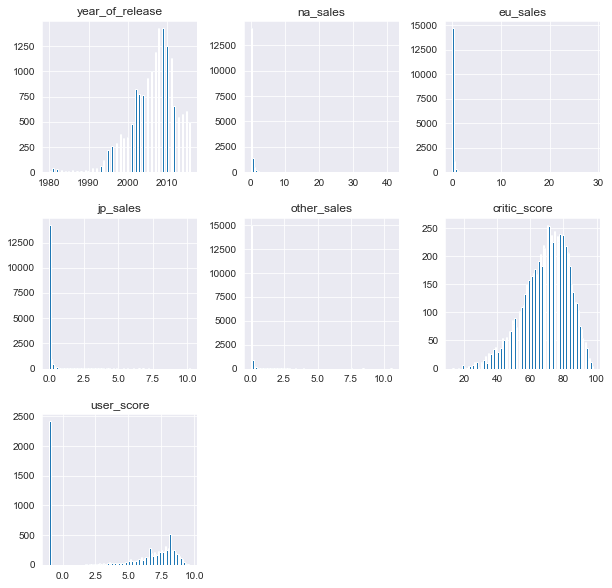

```python
# distribution histograms
data.hist(figsize=(10, 10), bins=100)
plt.show()
```

*Вывод*: данные представлены с 1980 по 2016 гг.  
Во всех столбцах с данными о количестве проданных копий игр - большой пик около 0, что говорит о том, что для многих игр было продано очень мало копий, либо ни одной копии. С другой стороны, есть выбросы в большую сторону: некоторые игры продавались десятками миллионов копий. Среднее значительно сдвинуто вправо от медианы. Но в большинстве случаев количество продаж игр не достигало и четверти миллиона.  
Большинство отзывов критиков сосредоточено между 70 и 80 (из 100), а пользователей - между 7.5 и 8 (из 10), причем для многих игр оценка пользователя еще уточняется (значение -1).

**НЕчисловые данные**

- Названия игр

```python
# number of unique games
print(f'Кол-во уникальных игр: {data.name.nunique()}')
```

```
Кол-во уникальных игр: 11559
```

```python
# unique games
sorted(data['name'].dropna().unique())
```

```
[' Beyblade Burst',
 ' Fire Emblem Fates',
 " Frozen: Olaf's Quest",
 ' Haikyu!! Cross Team Match!',
 ' Tales of Xillia 2',
 "'98 Koshien",
 '.hack//G.U. Vol.1//Rebirth',
 '.hack//G.U. Vol.2//Reminisce',
 '.hack//G.U. Vol.2//Reminisce (jp sales)',
 '.hack//G.U. Vol.3//Redemption',
 '.hack//Infection Part 1',
 '.hack//Link',
 '.hack//Mutation Part 2',
 '.hack//Outbreak Part 3',
 '.hack//Quarantine Part 4: The Final Chapter',
 '.hack: Sekai no Mukou ni + Versus',
 '007 Racing',
 '007: Quantum of Solace',
 '007: The World is not Enough',
 '007: Tomorrow Never Dies',
 '1 vs. 100',
 '1/2 Summer +',
 '10 Minute Solution',
 '100 All-Time Favorites',
 '100 Classic Books',
 '100 Classic Games',
 '1000 Cooking Recipes from ELLE à table',
 '1001 Touch Games',
 '101-in-1 Explosive Megamix',
 '101-in-1 Party Megamix Wii',
 '101-in-1 Sports Megamix',
 '101-in-1 Sports Party Megamix',
 '1080°: TenEighty Snowboarding',
 '11eyes: CrossOver',
 '12-Sai. Honto no Kimochi',
 '12-Sai. Koisuru Diary',
 '12Riven: The Psi-Climinal of Integral',
 '15 Days',
 '1701 A.D.',
 '18 Wheeler: American Pro Trucker',
```

[output cut: 946 more lines]

```
 'Bomberman II',
 'Bomberman Jetters',
 'Bomberman Land',
 'Bomberman Land Touch!',
 'Bomberman Land Touch! 2',
 'Bomberman Max 2: Blue Advance',
 'Bomberman Max 2: Red Advance',
 'Bomberman Party Edition',
 'Bomberman Story DS',
 'Bomberman Tournament',
 'Bomberman World',
 'Bomberman: Act Zero',
 'Boogie',
 'Boogie SuperStar',
 ...]
```

- Платформа

```python
# unique platforms
data['platform'].sort_values().unique()
```

```
array(['2600', '3DO', '3DS', 'DC', 'DS', 'GB', 'GBA', 'GC', 'GEN', 'GG',
       'N64', 'NES', 'NG', 'PC', 'PCFX', 'PS', 'PS2', 'PS3', 'PS4', 'PSP',
       'PSV', 'SAT', 'SCD', 'SNES', 'TG16', 'WS', 'Wii', 'WiiU', 'X360',
       'XB', 'XOne'], dtype=object)
```

```python
# number of platforms
print(f'Кол-во уникальных платформ: {data.platform.nunique()}')
```

```
Кол-во уникальных платформ: 31
```

```python
# number of games on each platform
data['platform'].value_counts()
```

```
PS2     2161
DS      2151
PS3     1331
Wii     1320
X360    1262
PSP     1209
PS      1197
PC       974
XB       824
GBA      822
GC       556
3DS      520
PSV      430
PS4      392
N64      319
XOne     247
SNES     239
SAT      173
WiiU     147
2600     133
NES       98
GB        98
DC        52
GEN       29
NG        12
SCD        6
WS         6
3DO        3
TG16       2
GG         1
PCFX       1
Name: platform, dtype: int64
```

- Жанр игры

```python
# unique genres
data['genre'].sort_values().unique()
```

```
array(['Action', 'Adventure', 'Fighting', 'Misc', 'Platform', 'Puzzle',
       'Racing', 'Role-Playing', 'Shooter', 'Simulation', 'Sports',
       'Strategy', nan], dtype=object)
```

```python
# number of games in each genre
data['genre'].value_counts()
```

```
Action          3369
Sports          2348
Misc            1750
Role-Playing    1498
Shooter         1323
Adventure       1303
Racing          1249
Platform         888
Simulation       873
Fighting         849
Strategy         683
Puzzle           580
Name: genre, dtype: int64
```

- Рейтинг

Рейтинг от организации ESRB:

- A0: «Adults Only 18+» — «Только для взрослых»
- E: «Everyone» — «Для всех»
- E10+: «Everyone 10 and older» — «Для всех от 10 лет и старше»
- EC: «Early childhood» — «Для детей младшего возраста»
- K-A: "Kids to Adults", in 1998 changed to E (Everyone)
- M: «Mature» — «Для взрослых»
- RP: «Rating Pending» — «Рейтинг ожидается»
- T: «Teen» — «Подросткам»

```python
# types of rating
sorted(data['rating'].dropna().unique())
```

```
['AO', 'E', 'E10+', 'EC', 'K-A', 'M', 'RP', 'T']
```

```python
# number of games of each rating type
data['rating'].value_counts()
```

```
E       3990
T       2961
M       1563
E10+    1420
EC         8
K-A        3
RP         3
AO         1
Name: rating, dtype: int64
```

*Вывод*: В данных представлено более 10 000 разных игр. Есть некорректные и странные названия игр, начинающиеся с пробела или ".hack//G.U. ...". В зависимости от задач исследования их стоит откорректировать, для данного исследования оставим такие названия, как есть.  
Игры представлены на 31 разной платформе, больше всего игр на PS2 и DS. C 1980го по 2016 гг всего по одной игре вышло на платформах GG и PCFX. Больше всего игр жанра "Действие" и "Спорт", а вот паззлов меньше всего. Имеются игры всех типов рейтинга ESRB, в том числе - устаревшего тип рейтинга "К-А", который теперь относится к "Е". Больше всего игр "Для всех" и для подростков.

### Обработка пропущенных значений

```python
# number of NaN
print('Количество пропущенных значений в каждом параметре:')
data.isna().sum()
```

```
Количество пропущенных значений в каждом параметре:
```

```
name                  2
platform              0
year_of_release     269
genre                 2
na_sales              0
eu_sales              0
jp_sales              0
other_sales           0
critic_score       8578
user_score         6701
rating             6766
dtype: int64
```

```python
# percentage of NaN
print('Процент пропущенных значений для каждого параметра:')
(data.isna().mean() * 100).sort_values(ascending=False)
```

```
Процент пропущенных значений для каждого параметра:
```

```
critic_score       51.3192
rating             40.4786
user_score         40.0897
year_of_release     1.6093
name                0.0120
genre               0.0120
platform            0.0000
na_sales            0.0000
eu_sales            0.0000
jp_sales            0.0000
other_sales         0.0000
dtype: float64
```

В данных с **оценкой и рейтингом игр** более 40 % пропущенных значений. Изучим данные, где значения пропущены одновременно в этих столбцах.

```python
# games without scores and rating (mask)
scores_na = data['user_score'].isna() & data['critic_score'].isna() & data['rating'].isna()
```

```python
# number of games without scores and rating
print(f'Кол-во игр без оценок и рейтинга: {len(data[scores_na])}')

# percentage of games without scores and rating
print(f'Доля игр без оценок и рейтинга: {len(data[scores_na]) / data.shape[0]}')
```

```
Кол-во игр без оценок и рейтинга: 6621
Доля игр без оценок и рейтинга: 0.39611127729584206
```

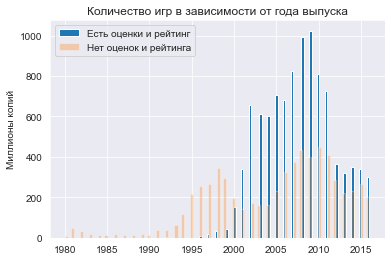

```python
# years of release of games with and without scores and rating
data[~scores_na]['year_of_release'].hist(bins=100)
data[scores_na]['year_of_release'].hist(bins=100, alpha=0.3)

plt.title('Количество игр в зависимости от года выпуска')
plt.ylabel('Миллионы копий')
plt.legend(['Есть оценки и рейтинг', 'Нет оценок и рейтинга'])
plt.show()
```

В данных 50% игр не имеют оценки критиков, и по 40% - не имеют оценки пользователей и рейтинга. Причем для 39% игр нет данных о рейтинге и оценках одновременно. Пропуски этих значений не характерны исключительно для игр, выпущенных в какой-то оределенный период, нет оценок и у многих игр, выпущенных недавно. Однако до 1996 года у всех игр этих данных нет, вероятно, потому что эти показатели не оценивались (так, ESRB была основана в 1994 году).

С 2005 года пропущенные значения, вероятно, связаны с другими факторами, например, для многих непопулятных игр оценки могла быть не выставлены. А возрастная категория могла быть присвоена другой организацией, европейской или японской, а не американской ESRB. Посмотрим, как зависит количество пропущенных значений оценок и рейтинга в зависимости от количества проданных копий, например, для Северной Америки.

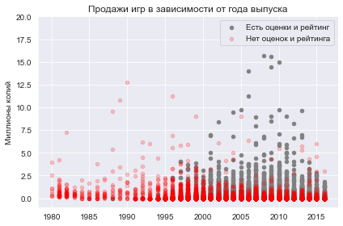

```python
# sales in North America
ax = data[~scores_na].plot(x='year_of_release', y='na_sales', kind='scatter', c='gray')
data[scores_na].plot(x='year_of_release', y='na_sales', kind='scatter', c='r', alpha=0.2, ax=ax)

plt.title('Продажи игр в зависимости от года выпуска')
plt.xlabel(None)
plt.ylabel('Миллионы копий')
plt.legend(['Есть оценки и рейтинг', 'Нет оценок и рейтинга'])
plt.ylim(-1, 20)
plt.tight_layout()
plt.show()
```

Видно, что для относительно современных игр, чьи продажи превышают 2 млн копий, обычно есть оценки пользователей и критиков, а также рейтинг.

Отсутствующие оценки можно заполнить, например, медианными значениями для платформы и диапазона продаж игр, но это представляется не совсем корректным. Найти для каждой игры ее рейтинг, вероятно, возможно, но представляется нецелесообразно для настоящего исследования. Оставим пропущенные значения оценок, как есть.

У 2 игр пропущено **название** и у 2 игр пропущен **жанр**. Вероятно, пропуски одновременные.

```python
# games without name or genre
data[(data['name'].isna()) | (data['genre'].isna())]
```

|  | name | platform | year_of_release | genre | na_sales | eu_sales | jp_sales | other_sales | critic_score | user_score | rating |
| --- | --- | --- | --- | --- | --- | --- | --- | --- | --- | --- | --- |
| 659 | NaN | GEN | 1993 | NaN | 1.78 | 0.53 | 0.00 | 0.08 | NaN | NaN | NaN |
| 14244 | NaN | GEN | 1993 | NaN | 0.00 | 0.00 | 0.03 | 0.00 | NaN | NaN | NaN |

Название и жанр пропущены одновременно, удалим эти игры.

```python
# drop games without name and genre
data = data.loc[(data['name'].notna()) & (data['genre'].notna())]
data.shape[0]
```

```
16713
```

**Год релиза** игры не указан для 269 игр (1.6%). Вероятно, причина в какой-то технологической ошибке, либо данные просто не были заполнены.

```python
# names and quantitiy of games without year of release
data[data['year_of_release'].isna()]['name'].value_counts()
```

```
LEGO Harry Potter: Years 5-7    7
Happy Feet Two                  4
Rock Band                       4
Test Drive Unlimited 2          3
Bejeweled 3                     3
                               ..
Jet X20                         1
Tony Hawk's Downhill Jam        1
Tribes: Aerial Assault          1
Big Beach Sports 2              1
Hakuouki: Shinsengumi Kitan     1
Name: name, Length: 232, dtype: int64
```

```python
# example of game without year of release
data.query('name == "LEGO Harry Potter: Years 5-7"')
```

|  | name | platform | year_of_release | genre | na_sales | eu_sales | jp_sales | other_sales | critic_score | user_score | rating |
| --- | --- | --- | --- | --- | --- | --- | --- | --- | --- | --- | --- |
| 1609 | LEGO Harry Potter: Years 5-7 | Wii | <NA> | Action | 0.69 | 0.42 | 0.0 | 0.12 | 76.0 | 7.8 | E10+ |
| 2132 | LEGO Harry Potter: Years 5-7 | X360 | <NA> | Action | 0.51 | 0.37 | 0.0 | 0.09 | 77.0 | 7.9 | E10+ |
| 2273 | LEGO Harry Potter: Years 5-7 | PS3 | <NA> | Action | 0.36 | 0.41 | 0.0 | 0.15 | 76.0 | 8.3 | E10+ |
| 3081 | LEGO Harry Potter: Years 5-7 | DS | <NA> | Action | 0.34 | 0.25 | 0.0 | 0.07 | 69.0 | -1.0 | E10+ |
| 4818 | LEGO Harry Potter: Years 5-7 | 3DS | <NA> | Action | 0.18 | 0.19 | 0.0 | 0.03 | 71.0 | 6.5 | E10+ |
| 6476 | LEGO Harry Potter: Years 5-7 | PSP | <NA> | Action | 0.10 | 0.10 | 0.0 | 0.06 | NaN | -1.0 | E10+ |
| 7210 | LEGO Harry Potter: Years 5-7 | PC | <NA> | Action | 0.05 | 0.14 | 0.0 | 0.03 | 80.0 | 8.5 | E10+ |
| 8059 | LEGO Harry Potter: Years 5-7 | PSV | 2012 | Action | 0.07 | 0.07 | 0.0 | 0.03 | 64.0 | 6.8 | E10+ |

Пропуски года выпуска сложно заполнить, основываясь, например, на названии игры, так как это могут быть игры, встречающиеся только 1 раз, а у игры с одним и тем же названием может быть разный год выпуска или платформа, то есть формально, это не одна и та же игра. Поскольку пропущенных данных мало, менее 2% - удалим эти строки.

```python
# drop rows with Nan in 'year_of_release'
data = data.dropna(subset=['year_of_release'])
data.isna().sum()
```

```
name                  0
platform              0
year_of_release       0
genre                 0
na_sales              0
eu_sales              0
jp_sales              0
other_sales           0
critic_score       8461
user_score         6605
rating             6676
dtype: int64
```

```python
# percentage of droped data:
print('Процент удаленных данных:')
print((1 - data.shape[0] / n_games_raw)*100)
```

```
Процент удаленных данных:
1.6212982351181626
```

### Добавление переменных

Посчитаем суммарные продажи во всех регионах.

```python
# adding total sales
data['total_sales'] = data[['na_sales','eu_sales','jp_sales', 'other_sales']].sum(axis = 1)
data.head()
```

|  | name | platform | year_of_release | genre | na_sales | eu_sales | jp_sales | other_sales | critic_score | user_score | rating | total_sales |
| --- | --- | --- | --- | --- | --- | --- | --- | --- | --- | --- | --- | --- |
| 0 | Wii Sports | Wii | 2006 | Sports | 41.36 | 28.96 | 3.77 | 8.45 | 76.0 | 8.0 | E | 82.54 |
| 1 | Super Mario Bros. | NES | 1985 | Platform | 29.08 | 3.58 | 6.81 | 0.77 | NaN | NaN | NaN | 40.24 |
| 2 | Mario Kart Wii | Wii | 2008 | Racing | 15.68 | 12.76 | 3.79 | 3.29 | 82.0 | 8.3 | E | 35.52 |
| 3 | Wii Sports Resort | Wii | 2009 | Sports | 15.61 | 10.93 | 3.28 | 2.95 | 80.0 | 8.0 | E | 32.77 |
| 4 | Pokemon Red/Pokemon Blue | GB | 1996 | Role-Playing | 11.27 | 8.89 | 10.22 | 1.00 | NaN | NaN | NaN | 31.38 |

Посмотрим на распределение общих продаж и их описательную статистику.

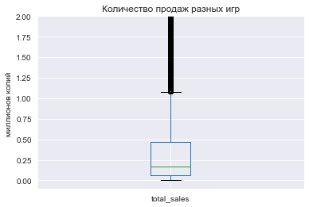

```
count    16444.0000
mean         0.5360
std          1.5588
min          0.0000
25%          0.0600
50%          0.1700
75%          0.4700
max         82.5400
Name: total_sales, dtype: float64
```

```python
# boxplot for total sales
data.boxplot('total_sales')
plt.title('Количество продаж разных игр')
plt.ylabel('миллионов копий ')
plt.ylim(-0.1, 2)
plt.show()
# descriptive statistics
data['total_sales'].describe()
```

Максимальное количество проданных копий одной игры по всем регионам - 82.5 миллиона, однако как правило продается не более 200 тыс копий игр. Для большинства игр - количество проданных копий не превышает полмиллиона.

## Исследовательский анализ данных

### Выбор периода для анализа продаж

#### Анализ продаж игр с 1980 по 2016гг

Посмотрим, каких игр было продано больше всего с 1980 по 2016гг, исходя из имеющихся данных.

```python
# топ-5 игр, с наибольшим количеством проданных копий
data.nlargest(5, 'total_sales')
```

|  | name | platform | year_of_release | genre | na_sales | eu_sales | jp_sales | other_sales | critic_score | user_score | rating | total_sales |
| --- | --- | --- | --- | --- | --- | --- | --- | --- | --- | --- | --- | --- |
| 0 | Wii Sports | Wii | 2006 | Sports | 41.36 | 28.96 | 3.77 | 8.45 | 76.0 | 8.0 | E | 82.54 |
| 1 | Super Mario Bros. | NES | 1985 | Platform | 29.08 | 3.58 | 6.81 | 0.77 | NaN | NaN | NaN | 40.24 |
| 2 | Mario Kart Wii | Wii | 2008 | Racing | 15.68 | 12.76 | 3.79 | 3.29 | 82.0 | 8.3 | E | 35.52 |
| 3 | Wii Sports Resort | Wii | 2009 | Sports | 15.61 | 10.93 | 3.28 | 2.95 | 80.0 | 8.0 | E | 32.77 |
| 4 | Pokemon Red/Pokemon Blue | GB | 1996 | Role-Playing | 11.27 | 8.89 | 10.22 | 1.00 | NaN | NaN | NaN | 31.38 |

Все 5 игр, у которых было продано наибольшее количество копий, согласно данному датасету, выпущены японской компанией Nintendo. Наибольшей популярностью пользовалась игра WiiSports (и ее вариации). Неудивительно, что эта игра стала рекордсменом по количеству наград. Вошла в топ-5 и знаменитая игра "Супербратья Марио", занесена в «Книгу рекордов Гиннесса» как самая продаваемая игра в истории. Замкнул пятерку Покемон.

Количество продаж игр связано с количеством выпускаемых игр. Посмотрим на динамику выпуска игр, начиная с 1980 г.

- **Динамика количества выпускаемых в год игр**

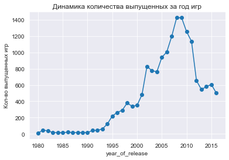

```python
# number of released games per year
(data
 .groupby('year_of_release')['name']
 .count()
 .plot(style='-o', grid=True)
 )

plt.title('Динамика количества выпущенных за год игр')
plt.ylabel('Кол-во выпущенных игр')
plt.show()
```

Видно, что до 1993 года выпускалось очень мало игр, а начиная с 1994 года начался стремительный рост вплоть до 2008 года, связанный, вероятно, с развитием технологий и индустрии. С 2009 года начался резкий спад в количестве выпускаемых игр, обусловленный, вероятно, мировым экономическим кризисом, начавшимся в 2008. Начиная с 2013 года падение количества выпусков игр остановилось, снижение в 2016 г может быть связано с тем, что данные для этого года неполные.

- **Динамика количества продаж игр в год**

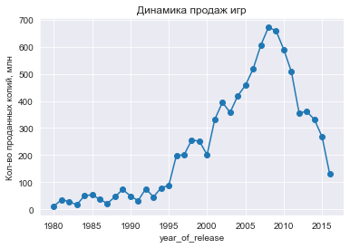

```python
# number of total sales per year
(data
 .groupby('year_of_release')['total_sales']
 .sum()
 .plot(style='-o', grid=True)
 )

plt.title('Динамика продаж игр')
plt.ylabel('Кол-во проданных копий, млн')
plt.show()
```

Динамика продаж похожа на динамику количества выпусков игр, это логично. До 2008 года количество выпускаемых игр росло - росло и количество продаж, затем наступил резкий спад. С 2012 года количество продаж игр перестало резко падать, за исключением последнего года в данных - 2016, вероятно по нему есть еще не все данные.

*Вывод:* поскольку анализ необходим для планирования работы на следующий год, вероятно не следует брать данные за все периоды, так как они очень разные. Возможно, следует взять лишь актуальные данные, например, с 2012 года, когда количество продаж перестало резко падать. Однако стоит посмотреть и на динамику других показателей, например, как менялись со временем продажи игр в зависимости от платформ.

- **Динамика продаж игр в зависимости от платформы**

```python
# number of total sales for each platform
(data.pivot_table(index='platform', values='total_sales', aggfunc='sum')
     .sort_values(by='total_sales', ascending=False)
)
```

| platform | total_sales |
| --- | --- |
| PS2 | 1233.56 |
| X360 | 961.24 |
| PS3 | 931.34 |
| Wii | 891.18 |
| DS | 802.78 |
| PS | 727.58 |
| PS4 | 314.14 |
| GBA | 312.88 |
| PSP | 289.53 |
| 3DS | 257.81 |
| PC | 255.76 |
| GB | 254.43 |
| XB | 251.57 |
| NES | 251.05 |
| N64 | 218.01 |
| SNES | 200.04 |
| GC | 196.73 |
| XOne | 159.32 |
| 2600 | 86.48 |
| WiiU | 82.19 |
| PSV | 53.81 |
| SAT | 33.59 |
| GEN | 28.35 |
| DC | 15.95 |
| SCD | 1.86 |
| NG | 1.44 |
| WS | 1.42 |
| TG16 | 0.16 |
| 3DO | 0.10 |
| GG | 0.04 |
| PCFX | 0.03 |

Первые 6 платформ имеют самые большие продажи, выделим их в самые популярные платформы.

```python
# leading platforms
leading_platforms = (data.pivot_table(index='platform', values='total_sales', aggfunc='sum')
     .sort_values(by='total_sales', ascending=False)
     .head(6)).index

leading_platforms
```

```
Index(['PS2', 'X360', 'PS3', 'Wii', 'DS', 'PS'], dtype='object', name='platform')
```

Лидерами по количеству общих продаж за все года являются платформы PS2,3, X360, Wii, DS. Однако, сейчас эти платформы могут быть уже неактуальны: несмотря на большие продажи на этих платформах в прошлом, в настоящее время они могут быть устаревшими. Стоит посмотреть на количество продаж в зависимости от платформы в динамике.

```python
# number of sales for each platform per year
platforms_per_year = (data
 .groupby(['year_of_release', 'platform'], as_index=False)['total_sales']
 .sum()
 )
platforms_per_year.head()
```

|  | year_of_release | platform | total_sales |
| --- | --- | --- | --- |
| 0 | 1980 | 2600 | 11.38 |
| 1 | 1981 | 2600 | 35.68 |
| 2 | 1982 | 2600 | 28.88 |
| 3 | 1983 | 2600 | 5.84 |
| 4 | 1983 | NES | 10.96 |

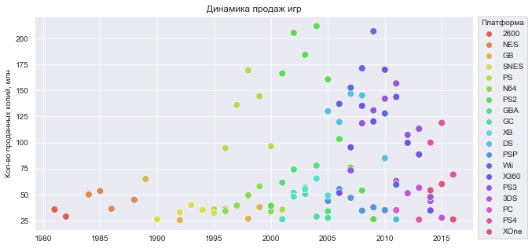

```python
# number of total sales per year for popular platforms (total sales > 25 mln)
plt.figure(figsize=(10,5))
sns.scatterplot(data=platforms_per_year.query('total_sales > 25'),
                x='year_of_release',
                y='total_sales',
                hue='platform',
                palette='hls',
                s=80)

plt.legend(bbox_to_anchor=(1.01, 1), loc='upper left', borderaxespad=0, title='Платформа')
plt.title('Динамика продаж игр')
plt.xlabel(None)
plt.ylabel('Кол-во проданных копий, млн')
plt.show()
```

Платформы появляются и исчезают, видно, что "время жизни" популярных плотформ - около 5 лет. Если в 80е лидирующей платформой была 2600, то пики продаж пришлись на PS2 в 2001-2005 и Wii в 2005-2010, в последние годы лидируют PS4 и XOne.

Высокие продажи у PS2 в 2001-2004 гг к 2010 году сильно упали, ее сменили Wii и DS, но и их продажи к 2010 тоже упали. Пришедшие на смену PS3 и X360 к 2015 году, кажется, также стали менее популярными.

Посмотрим только на топ-10 платформ - продажи игр на которых лидировали в какой-то период.

```python
# leading platforms per year
leading_platforms_per_year = (platforms_per_year
 .sort_values('total_sales', ascending=False)
 .drop_duplicates(subset='platform', keep = 'first')
 .head(10))

leading_platforms_per_year
```

|  | year_of_release | platform | total_sales |
| --- | --- | --- | --- |
| 125 | 2004 | PS2 | 211.81 |
| 171 | 2009 | Wii | 206.97 |
| 179 | 2010 | X360 | 170.03 |
| 77 | 1998 | PS | 169.49 |
| 184 | 2011 | PS3 | 156.78 |
| 147 | 2007 | DS | 146.94 |
| 222 | 2015 | PS4 | 118.90 |
| 122 | 2004 | GBA | 77.91 |
| 127 | 2004 | XB | 65.42 |
| 20 | 1989 | GB | 64.97 |

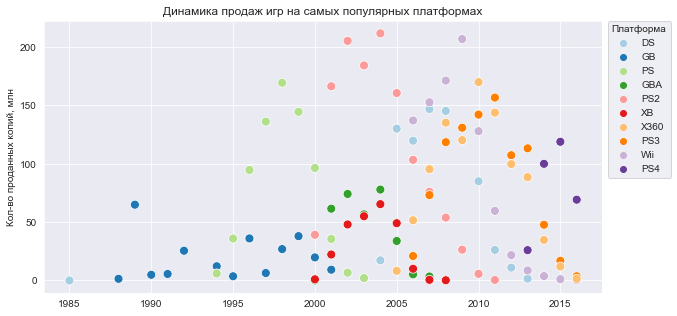

```python
# number of total sales per year for leading platforms (top-10)
plt.figure(figsize=(10,5))
sns.scatterplot(data=platforms_per_year.query('platform in @leading_platforms_per_year.platform'),
                x='year_of_release',
                y='total_sales',
                hue='platform',
                palette='Paired',
                s=80)

plt.legend(bbox_to_anchor=(1.01, 1), loc='upper left', borderaxespad=0, title='Платформа')
plt.title('Динамика продаж игр на самых популярных платформах')
plt.xlabel(None)
plt.ylabel('Кол-во проданных копий, млн')
plt.show()
```

Посмотрим, как меняются продажи для 6 самых продаваемых платформ по-отдельности.

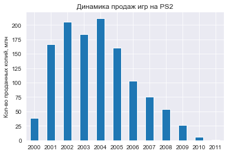

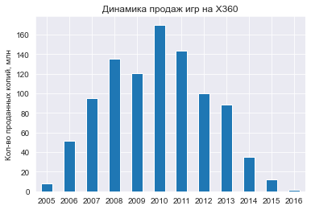

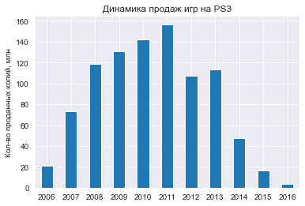

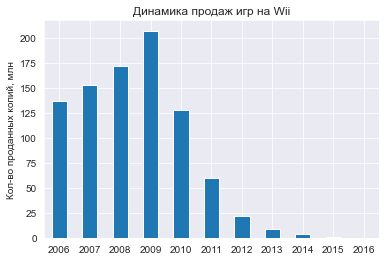

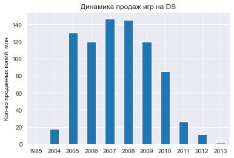

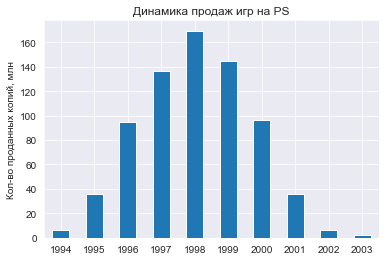

```python
# leading platforms, barplot
for platf in leading_platforms:
    platforms_per_year[platforms_per_year['platform'] == platf].plot.bar(
                x='year_of_release',
                y='total_sales',
                rot=0,
                legend=None)
    plt.title(f'Динамика продаж игр на {platf}')
    plt.xlabel(None)
    plt.ylabel('Кол-во проданных копий, млн')
    plt.show()
```

Из графиков видно, что максимальные продажи на популярных платформах наблюдаются в течении 5-6 лет, а затем идут на спад, рост и спад продаж для одних платформ плавные, а для других - резкие.

**Вывод:** При планировании рекламных кампаний и продаж игр на следующий год следует учитывать, для какой платформы игра. Не стоит делать ставку на платформы, популярные ранее, но чье "время жизни" подходит к концу - динамика продаж идет на спад по сравнению с прошлыми годами.

Исходя из динамики продаж игр и динамики выпуска игр, а также "времени жизни" платформ, в анализе следует учитывать только актуальный период: с 2012 по 2016 гг, причем стоит помнить, что данные за 2016 год неполные.

#### Анализ продаж игр за последние 5 лет, с 2012 по 2016 годы

```python
# dataframe with actual data (2012-2016)
actual_data = data[data['year_of_release'] >= 2012]
actual_data['year_of_release'].unique()
```

```
<IntegerArray>
[2013, 2015, 2012, 2014, 2016]
Length: 5, dtype: Int32
```

```python
# dataframe with actual data (2012-2015)
actual_data2 = data[(data['year_of_release'] >= 2012) & (data['year_of_release'] <= 2015)]
actual_data2['year_of_release'].unique()
```

```
<IntegerArray>
[2013, 2015, 2012, 2014]
Length: 4, dtype: Int32
```

```python
# get information about the data
actual_data.info()
```

```
<class 'pandas.core.frame.DataFrame'>
Int64Index: 2886 entries, 16 to 16714
Data columns (total 12 columns):
 #   Column           Non-Null Count  Dtype
---  ------           --------------  -----
 0   name             2886 non-null   object
 1   platform         2886 non-null   object
 2   year_of_release  2886 non-null   Int32
 3   genre            2886 non-null   object
 4   na_sales         2886 non-null   float64
 5   eu_sales         2886 non-null   float64
 6   jp_sales         2886 non-null   float64
 7   other_sales      2886 non-null   float64
 8   critic_score     1312 non-null   float64
 9   user_score       1663 non-null   float64
 10  rating           1611 non-null   object
 11  total_sales      2886 non-null   float64
dtypes: Int32(1), float64(7), object(4)
memory usage: 284.7+ KB
```

```python
# descriptive statistics
actual_data.describe()
```

|  | year_of_release | na_sales | eu_sales | jp_sales | other_sales | critic_score | user_score | total_sales |
| --- | --- | --- | --- | --- | --- | --- | --- | --- |
| count | 2886.0000 | 2886.0000 | 2886.0000 | 2886.0000 | 2886.0000 | 1312.0000 | 1663.0000 | 2886.0000 |
| mean | 2013.9168 | 0.2048 | 0.1756 | 0.0667 | 0.0541 | 72.2584 | 6.0300 | 0.5012 |
| std | 1.4118 | 0.5667 | 0.5053 | 0.2416 | 0.1646 | 12.6871 | 2.5554 | 1.2492 |
| min | 2012.0000 | 0.0000 | 0.0000 | 0.0000 | 0.0000 | 13.0000 | -1.0000 | 0.0100 |
| 25% | 2013.0000 | 0.0000 | 0.0000 | 0.0000 | 0.0000 | 66.0000 | 5.3000 | 0.0400 |
| 50% | 2014.0000 | 0.0300 | 0.0300 | 0.0100 | 0.0100 | 74.0000 | 6.8000 | 0.1200 |
| 75% | 2015.0000 | 0.1700 | 0.1400 | 0.0500 | 0.0400 | 81.0000 | 7.8000 | 0.4300 |
| max | 2016.0000 | 9.6600 | 9.0900 | 4.3900 | 3.9600 | 97.0000 | 9.3000 | 21.0500 |

В отфильтрованном датасете для всех данных по продажам среднее значение значительно сдвинуто вправо от медианы, что говорит о наличии выбросов в большую сторону. В последние годы продажи игр упали, и в общем по всем регионам продавалось как правило около 100 тыс копий.

```python
# percentage of NaN
print('Процент пропущенных значений для каждого параметра:')
(actual_data.isna().mean() * 100).sort_values(ascending=False)
```

```
Процент пропущенных значений для каждого параметра:
```

```
critic_score       54.5392
rating             44.1788
user_score         42.3770
name                0.0000
platform            0.0000
year_of_release     0.0000
genre               0.0000
na_sales            0.0000
eu_sales            0.0000
jp_sales            0.0000
other_sales         0.0000
total_sales         0.0000
dtype: float64
```

В данных с рейтингом и оценками по прежнему более 40% пропущенных значений. В данных с оценками оставим пропуски как есть, а в данных рейтинга (*object*) заменим NaN на "None",чтобы эти данные отображались при анализе,

```python
actual_data['rating']
```

```
16         M
23         M
31       NaN
33       NaN
34         M
        ...
16703    NaN
16707    NaN
16710    NaN
16712    NaN
16714    NaN
Name: rating, Length: 2886, dtype: object
```

```python
# rating: replacing NaN with "None"
actual_data.rating = actual_data.rating.fillna('None')
actual_data.rating.value_counts()
```

```
None    1275
M        498
T        412
E        395
E10+     306
Name: rating, dtype: int64
```

- **Зависимость продаж от платформы**

Посмотрим на актуальные значение количества игр, выпущенных на различных платформах, и их продажи.

```python
# number of games on different platforms
actual_data.platform.value_counts()
```

```
PS3     493
PSV     411
3DS     396
PS4     392
X360    292
PC      250
XOne    247
PSP     173
WiiU    147
Wii      54
DS       31
Name: platform, dtype: int64
```

```python
# total sales per platform, mln
actual_data.groupby('platform')['total_sales'].sum().sort_values(ascending=False)
```

```
platform
PS4     314.14
PS3     288.79
X360    236.54
3DS     194.61
XOne    159.32
WiiU     82.19
PC       62.65
PSV      49.18
Wii      35.37
DS       12.55
PSP      11.19
Name: total_sales, dtype: float64
```

```python
# 5 leading platforms
leading_platforms = (
    actual_data
    .groupby('platform')['total_sales']
    .sum()
    .sort_values(ascending=False)
    .head()
    .index
)

leading_platforms
```

```
Index(['PS4', 'PS3', 'X360', '3DS', 'XOne'], dtype='object', name='platform')
```

```python
# number of sales for each platform for 2012-2016
actual_platforms_per_year = (actual_data
 .groupby(['year_of_release', 'platform'], as_index=False)['total_sales']
 .sum()
 )
```

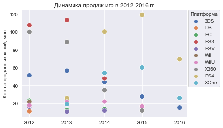

```python
# dinamic of sales for each platform for 2012-2016
sns.scatterplot(data=actual_platforms_per_year.query('total_sales > 10'),
                x='year_of_release',
                y='total_sales',
                hue='platform',
                palette='deep',
                s=100)

plt.legend(bbox_to_anchor=(1.01, 1), loc='upper left', borderaxespad=0, title='Платформа')
plt.xticks(range(2012, 2017, 1))
plt.title('Динамика продаж игр в 2012-2016 гг')
plt.xlabel(None)
plt.ylabel('Кол-во проданных копий, млн')
plt.show()
```

В последние годы больше всего продается игр на PS4, популярна также XOne. Снижение продаж игр на этих платформах в 2016 г вероятно объясняется тем, что данные за этот год неполные. Высокие продажи PS3, X360 и 3DS идут на спад.

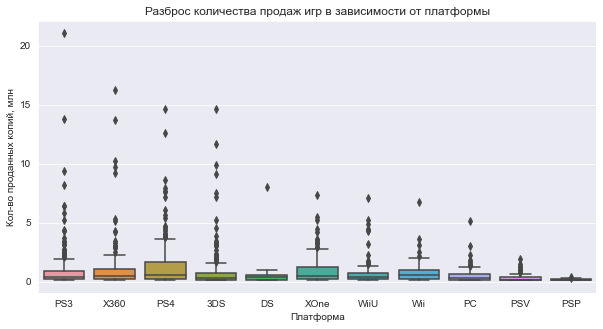

```python
# boxplots of total sales for each platform
plt.figure(figsize=(10,5))
sns.boxplot(
    data=actual_data.query('total_sales > 0.1'),
    x='platform',
    y='total_sales')

plt.title('Разброс количества продаж игр в зависимости от платформы')
plt.xlabel('Платформа')
plt.ylabel('Кол-во проданных копий, млн')
plt.show()
```

Посмотрим на данный график без больших выбросов.

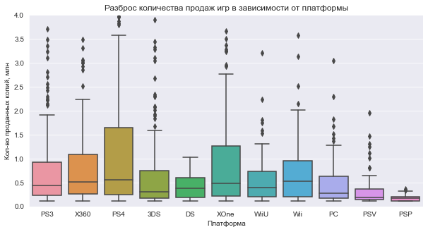

```python
# boxplots of total sales for each platform
plt.figure(figsize=(10,5))
sns.boxplot(
    data=actual_data.query('total_sales > 0.1'),
    x='platform',
    y='total_sales')

plt.title('Разброс количества продаж игр в зависимости от платформы')
plt.xlabel('Платформа')
plt.ylabel('Кол-во проданных копий, млн')
plt.ylim(0,4)
plt.show()
```

Почти для всех платформ есть выбросы в количестве продаж в большую сторону. У платформ PS3,4, X360, 3DS они высокие, что говорит о возможности покупок большого числа копий игр на этих платформах. Однако Q3 (а значит - 75% значений) самые высокие у платформ PS4 и XOne.

**Вывод**: При планировании рекламных кампаний на следующий год стоит обратить внимание на игры на платформах PS4 и XOne. А вот высокие продажи PS3, X360 и 3DS идут на спад, наверное, не стоит делать ставку на продажу игр на этих платформах.

- **Зависимость продаж от мнения пользователей и критиков**

```python
# lower limit of "normal" sales in 2012-2016 (Q1-1.5*IQR)
if 2.5 * actual_data['total_sales'].quantile(0.25) - 1.50 * actual_data['total_sales'].quantile(0.75) < 0:
    print(actual_data['total_sales'].min())
else:
    print(2.5 * actual_data['total_sales'].quantile(0.25) - 1.50 * actual_data['total_sales'].quantile(0.75))
```

```
0.01
```

Посмотрим, как влияют на продажи внутри одной из популярных платформ (**PS4**) отзывы пользователей и критиков.

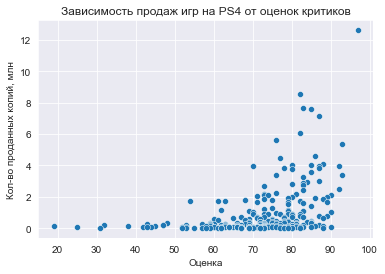

```python
# scatterplot: total sales of PS4 games(critics' scores)
sns.scatterplot(
    data=actual_data.query('platform == "PS4" and total_sales > 0.01'),
    x='critic_score',
    y='total_sales')

plt.title('Зависимость продаж игр на PS4 от оценок критиков')
plt.xlabel('Оценка')
plt.ylabel('Кол-во проданных копий, млн')
plt.show()
```

```python
# Pearson correlation coefficients, 2012-2016
actual_data.query('platform == "PS4"')[['total_sales', 'critic_score']].corr()
```

|  | total_sales | critic_score |
| --- | --- | --- |
| total_sales | 1.0000 | 0.4066 |
| critic_score | 0.4066 | 1.0000 |

Посмотрим, сильно ли будет отличаться коэффициент корреляции, если исключить из анализа 2016 г, за который нет полных данных.

```python
# Pearson correlation coefficients, 2012-2015
actual_data2.query('platform == "PS4"')[['total_sales', 'critic_score']].corr()
```

|  | total_sales | critic_score |
| --- | --- | --- |
| total_sales | 1.0000 | 0.4318 |
| critic_score | 0.4318 | 1.0000 |

По графику видно, что у игр на PS4 с высокими продажами и оцеки критиков как правило высокие (самые высокие оценки, выше 90 из 100 только у хорошо продаваемых игр). Однако однозначной прямой зависимости нет: высокие оцеки (выше 80) критики ставили и играм с низкими продажами. Для игр с низкими оценками критиков (< 50) все более однозначно - продажи у них всегда низки. Коэффициент корреляции указывает на слабую взаимосвязь между количеством продаж игр и оценкой критиков. Исключение из анализа "неполного" 2016 г ситуацию значительно не меняет.

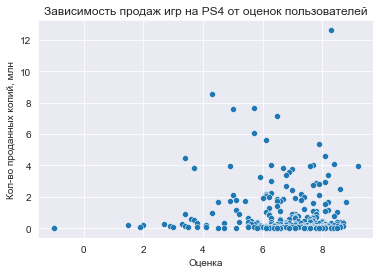

```python
# scatterplot: total sales of PS4 games(users' scores)
sns.scatterplot(
    data=actual_data.query('platform == "PS4" and total_sales > 0.01'),
    x='user_score',
    y='total_sales')

plt.title('Зависимость продаж игр на PS4 от оценок пользователей')
plt.xlabel('Оценка')
plt.ylabel('Кол-во проданных копий, млн')
plt.show()
```

```python
# Pearson correlation coefficients, 2012-2016
actual_data.query('platform == "PS4"')[['total_sales', 'user_score']].corr()
```

|  | total_sales | user_score |
| --- | --- | --- |
| total_sales | 1.0000 | 0.0291 |
| user_score | 0.0291 | 1.0000 |

```python
# Pearson correlation coefficients, 2012-2015
actual_data2.query('platform == "PS4"')[['total_sales', 'user_score']].corr()
```

|  | total_sales | user_score |
| --- | --- | --- |
| total_sales | 1.0000 | 0.0421 |
| user_score | 0.0421 | 1.0000 |

А вот мнения пользователей не сильно связано с количеством продаж игр. Пользователи могут поставить низкую оценку как хорошо продаваемым играм, так высокую оценку - низкопродаваемым. Отсутсвие взаимосвязи подтверждает и коэффициент корреляции, близкий к 0.

Посмотрим, повторяют ли такие тенденции другие платформы.

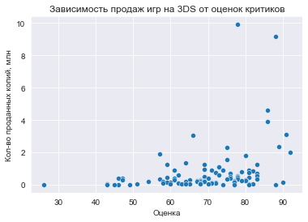

```
Коэффициент корреляции Пирсона
```

|  | total_sales | critic_score |
| --- | --- | --- |
| total_sales | 1.0000 | 0.3208 |
| critic_score | 0.3208 | 1.0000 |

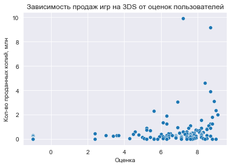

```
Коэффициент корреляции Пирсона
```

|  | total_sales | user_score |
| --- | --- | --- |
| total_sales | 1.000 | 0.264 |
| user_score | 0.264 | 1.000 |

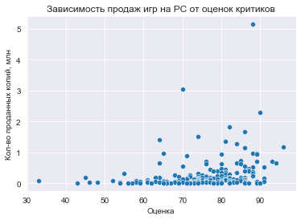

```
Коэффициент корреляции Пирсона
```

|  | total_sales | critic_score |
| --- | --- | --- |
| total_sales | 1.0000 | 0.2372 |
| critic_score | 0.2372 | 1.0000 |

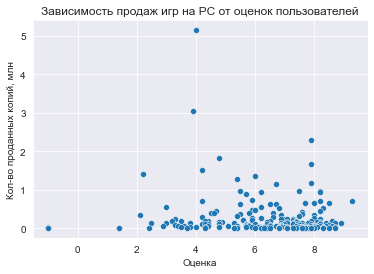

```
Коэффициент корреляции Пирсона
```

|  | total_sales | user_score |
| --- | --- | --- |
| total_sales | 1.0000 | -0.0572 |
| user_score | -0.0572 | 1.0000 |

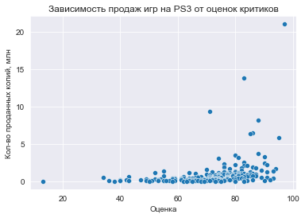

```
Коэффициент корреляции Пирсона
```

|  | total_sales | critic_score |
| --- | --- | --- |
| total_sales | 1.0000 | 0.3315 |
| critic_score | 0.3315 | 1.0000 |

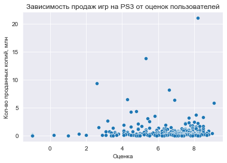

```
Коэффициент корреляции Пирсона
```

|  | total_sales | user_score |
| --- | --- | --- |
| total_sales | 1.0000 | 0.1004 |
| user_score | 0.1004 | 1.0000 |

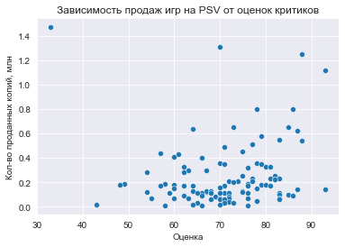

```
Коэффициент корреляции Пирсона
```

|  | total_sales | critic_score |
| --- | --- | --- |
| total_sales | 1.0000 | 0.0945 |
| critic_score | 0.0945 | 1.0000 |

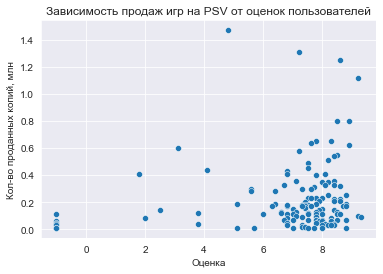

```
Коэффициент корреляции Пирсона
```

|  | total_sales | user_score |
| --- | --- | --- |
| total_sales | 1.0000 | 0.1312 |
| user_score | 0.1312 | 1.0000 |

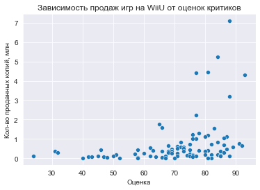

```
Коэффициент корреляции Пирсона
```

|  | total_sales | critic_score |
| --- | --- | --- |
| total_sales | 1.0000 | 0.3484 |
| critic_score | 0.3484 | 1.0000 |

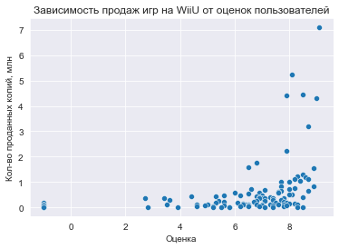

```
Коэффициент корреляции Пирсона
```

|  | total_sales | user_score |
| --- | --- | --- |
| total_sales | 1.0000 | 0.3391 |
| user_score | 0.3391 | 1.0000 |

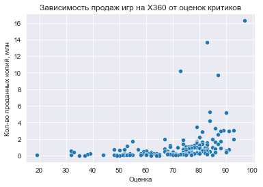

```
Коэффициент корреляции Пирсона
```

|  | total_sales | critic_score |
| --- | --- | --- |
| total_sales | 1.0000 | 0.3606 |
| critic_score | 0.3606 | 1.0000 |

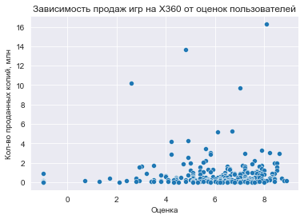

```
Коэффициент корреляции Пирсона
```

|  | total_sales | user_score |
| --- | --- | --- |
| total_sales | 1.0000 | 0.0668 |
| user_score | 0.0668 | 1.0000 |

[2 more figures not shown]

```
Коэффициент корреляции Пирсона
```

|  | total_sales | user_score |
| --- | --- | --- |
| total_sales | 1.0000 | 0.0853 |
| user_score | 0.0853 | 1.0000 |

```python
for i, group in actual_data.groupby('platform'):
    # scatterplot: total sales of PS4 games(critics' scores)
    if (
        group['critic_score'].count() > 30 and
        group['user_score'].count() > 30 and
        i != 'PS4'):
        sns.scatterplot(data=group, x='critic_score', y='total_sales')
        plt.title(f'Зависимость продаж игр на {i} от оценок критиков')
        plt.xlabel('Оценка')
        plt.ylabel('Кол-во проданных копий, млн')
        plt.show()
        # Pearson correlation coefficients
        print('Коэффициент корреляции Пирсона')
        display(group[['total_sales', 'critic_score']].corr())
        # scatterplot: total sales of PS4 games(users' scores)
        sns.scatterplot(data=group, x='user_score', y='total_sales')
        plt.title(f'Зависимость продаж игр на {i} от оценок пользователей')
        plt.xlabel('Оценка')
        plt.ylabel('Кол-во проданных копий, млн')
        plt.show()
        # Pearson correlation coefficients
        print('Коэффициент корреляции Пирсона')
        display(group[['total_sales', 'user_score']].corr())
```

**Вывод:** Вероятно, критики оценивают разные игры, не зависимо от их продаж, но в дальнейшем, их мнение вносит вклад - у игр с высокими продажами оценки критиков как правило высокие. Это хорошо видно по продажам игр на самой популярной в последнее время платформе - PS4. Для другой популярной платформы - XOne - картина похожая. Для менее популярных платформ (например, PS3 и X360) игр с большими продажами меньше, поэтому и связь оценки с продажами у них слабее (как правило, у игр с большими продажами оценки критиков высокие). Платформы PC и PSV "подтверждают" предположение, что чем меньше продаж у игр на определенной платформе, тем, как правило, меньше и связь между оценкой критиков и количеством проданных копий игр.

- **Зависимость продаж от жанров игр**

Посмотрим на распределение продаж игр в зависимости от жанра, общее количество игр каждого жанра и медианные значения количество их продаж.

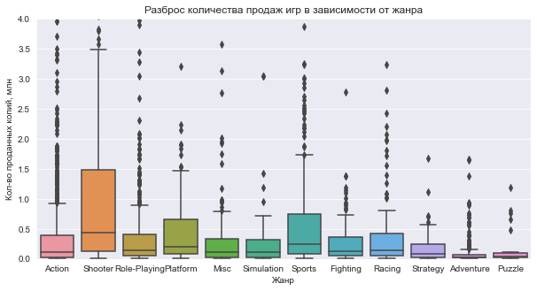

```python
# boxplots of total sales for each genre
plt.figure(figsize=(10,5))
sns.boxplot(
    data=actual_data,
    x='genre',
    y='total_sales')

plt.title('Разброс количества продаж игр в зависимости от жанра')
plt.xlabel('Жанр')
plt.ylabel('Кол-во проданных копий, млн')
plt.ylim(0, 4)
plt.show()
```

```python
# number and median sales of games with different genre
(actual_data
    .groupby('genre')['total_sales']
    .agg(['median', 'count'])
    .rename(columns={'median': 'Медиана кол-ва продаж, млн', 'count': 'Количество игр'})
    .sort_values(by='Медиана кол-ва продаж, млн', ascending=False)
    )
```

| genre | Медиана кол-ва продаж, млн | Количество игр |
| --- | --- | --- |
| Shooter | 0.440 | 235 |
| Sports | 0.240 | 268 |
| Platform | 0.210 | 85 |
| Role-Playing | 0.140 | 370 |
| Racing | 0.140 | 115 |
| Fighting | 0.130 | 109 |
| Action | 0.120 | 1031 |
| Misc | 0.120 | 192 |
| Simulation | 0.120 | 80 |
| Strategy | 0.080 | 71 |
| Puzzle | 0.045 | 28 |
| Adventure | 0.030 | 302 |

**Вывод:** За 2012-2016 гг стабильно продавались игры жанра "Shooter", но самые большие продажи у отдельных игр и самое большое количество игр - в жанре "Action". Также хорошо продавались игры жанра 'Sports'. А вот стратегии, паззлы и приключения продавались хуже всего, хотя игр Adventure достаточно много.

### Портрет пользователя каждого региона

В зависимости от региона продажи игр могут сильно отличаться, возможно, в Японии могут быть более популярны игры одних жанров, а в Европе - других. Чтобы корректнее продумать рекламные кампании, следует проверить, отличаются ли и как продажи игр по разным регионам.

```python
# define function to get pivot table for different regions
def get_pivot_table(df, factor):
    """
    Функция получает датафрейм (df) и название столбца (factor) -
    параметр, который может влиять на продажи.
    Cтроит сводную таблицу и график с процентом продаж игр внутри
    каждого региона в зависимости от значений столбца factor.

    """
    # pivot table
    piv_tbl = (df.pivot_table(
        index=factor,
        values=['na_sales', 'eu_sales',	'jp_sales', 'total_sales'],
        aggfunc='sum')
    .apply(lambda x: x / x.sum())
    .mul(100)
    .round(2)
    .sort_values(by='total_sales', ascending=False)
    .transpose()
    )

    # bar chart
    (piv_tbl
     .plot.bar(rot=0, figsize=(12,5))
     )
    plt.title(f'Продажи игр в разных регионах в зависимости от {factor}',
              fontsize=14)
    plt.ylabel('Процент от продаж по региону')
    plt.xlabel('Регион')
    plt.show()

    # percentage of sales in the region depending on factor
    display(piv_tbl
     .stack()
     .groupby(level=0, group_keys=False)
     .nlargest(5)
     )
```

#### Самые популярные платформы в каждом регионе

Посмотрим на зависимость продаж игр от платформы для каждого региона.

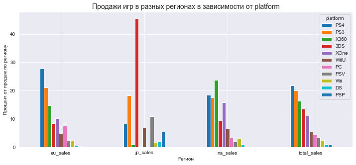

```
             platform
eu_sales     PS4         27.84
             PS3         21.08
             X360        14.70
             XOne        10.18
             3DS          8.41
jp_sales     3DS         45.59
             PS3         18.32
             PSV         10.93
             PS4          8.29
             WiiU         6.76
na_sales     X360        23.70
             PS4         18.40
             PS3         17.49
             XOne        15.76
             3DS          9.36
total_sales  PS4         21.72
             PS3         19.96
             X360        16.35
             3DS         13.45
             XOne        11.01
dtype: float64
```

```python
# bar chart and pivot table
get_pivot_table(actual_data, 'platform')
```

#### Самые популярные жанры в каждом регионе

Вероятно, популярность жанра игр также будет отличаться между Европой, Америкой и Японией. Посмотрим на зависимость продаж в зависимости от жанра игр для каждого региона.

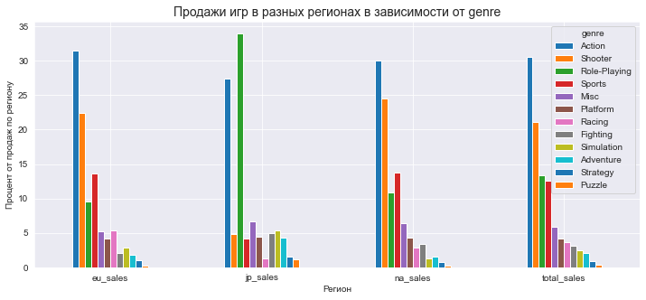

```
             genre
eu_sales     Action          31.44
             Shooter         22.39
             Sports          13.63
             Role-Playing     9.58
             Racing           5.38
jp_sales     Role-Playing    33.98
             Action          27.42
             Misc             6.68
             Simulation       5.41
             Fighting         4.90
na_sales     Action          30.09
             Shooter         24.50
             Sports          13.80
             Role-Playing    10.83
             Misc             6.46
total_sales  Action          30.50
             Shooter         21.07
             Role-Playing    13.33
             Sports          12.52
             Misc             5.88
dtype: float64
```

```python
# bar chart and pivot table
get_pivot_table(actual_data, 'genre')
```

**Вывод:** Предпочтения по жанрам также очень отличны для Японии.Во всех регионах игры жанра Действие очень популярны, но в Японии лидируют ролевые игры, а в Европе и Америке вторые по популярности "стрелялки", в Японии совершенно не популярные.

#### Влияние рейтинга ESRB на продажи в каждом регионе

Может быть так, что для разных регионов возрастные категории людей, играющих в игры также отличаются.

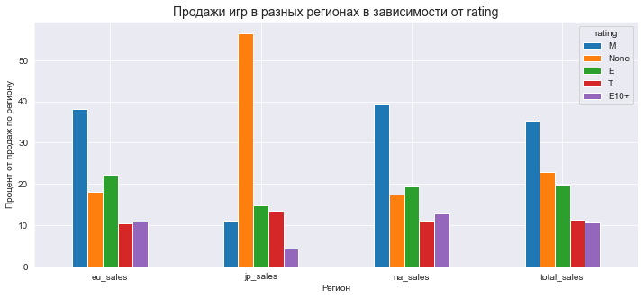

```
             rating
eu_sales     M         38.27
             E         22.30
             None      18.05
             E10+      10.92
             T         10.45
jp_sales     None      56.52
             E         14.71
             T         13.51
             M         11.01
             E10+       4.25
na_sales     M         39.18
             E         19.35
             None      17.48
             E10+      12.81
             T         11.17
total_sales  M         35.26
             None      22.87
             E         19.85
             T         11.26
             E10+      10.75
dtype: float64
```

```python
# bar chart and pivot table
get_pivot_table(actual_data, 'rating')
```

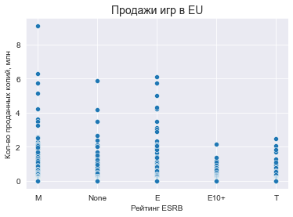

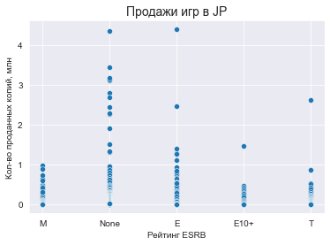

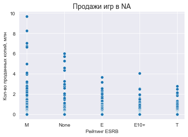

```python
# scatterplots for each region
for reg in ['eu_sales', 'jp_sales', 'na_sales']:
    sns.scatterplot('rating', reg, data=actual_data)
    plt.title(f'Продажи игр в {reg[0:2].upper()}',
             fontsize=14)
    plt.ylabel('Кол-во проданных копий, млн')
    plt.xlabel('Рейтинг ESRB')
    plt.show()
```

**Вывод:** Процент продаж игр разного рейтинга ESRB почти одинаков в Северной Америке и Европе. В Европе и Северной Америке, в целом, больше продается игр "Для взрослых", кроме того в Европе популярны игры "Для всех". Для Японии картина отличается - больше всего проданных игр не имеют рейтинга ESRB. Тут стоит учесть, что ESRB — это американская организация, она выдаёт рейтинги в Америке, Канаде и Мексике. В Японии же и Европе есть свои агенства по выдаче рейтинга. Вероятно, для того, чтобы корректнее оценить влияние возрастной категории на продажи игр, для каждого региона продаж лучше запрашивать локальный рейтинг.

## Проверка гипотез

Пользовательские оценки, по-видимому, существенно не влияют на продажи игр. А вот жанр игр важен. Проверим статистически, различаются ли средние оценки пользователей для игр на популярных платформах и обычных, а также самого популярного жанра и просто популярного.

**1. Сравним средние пользовательские рейтинги платформ Xbox One и PC** (помня, что в данных хначение "-1" указывает на то, что оценка еще не определена).

H0: cредние пользовательские рейтинги платформ Xbox One и PC одинаковые;

H1: cредние пользовательские рейтинги платформ Xbox One и PC различны.

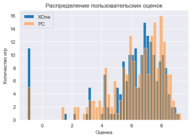

```python
# distribution of user scores
actual_data.query('platform=="XOne"')['user_score'].hist(bins=50)
actual_data.query('platform=="PC"')['user_score'].hist(bins=50, alpha=0.5)

plt.title('Распределение пользовательских оценок')
plt.ylabel('Количество игр')
plt.xlabel('Оценка')
plt.legend(['XOne', 'PC'])
plt.show()
```

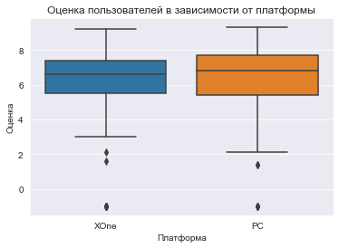

```python
# boxplot for user scores
sns.boxplot(
    data=actual_data.query('platform=="XOne" or platform=="PC"'),
    x='platform',
    y='user_score')

plt.title('Оценка пользователей в зависимости от платформы')
plt.xlabel('Платформа')
plt.ylabel('Оценка')
plt.show()
```

Кажется, что оценки для данных платформ не особо отличаются. Проведем статистический анализ для проверки этого предположения. Выборки достаточно велики, чтобы точно оценить дисперсию каждой генеральной совокупности по отдельности, поэтому объединять их для оценки дисперсии не будем.

```python
# Student's t-test for two independent samples
alpha = .05

results = st.ttest_ind(
    actual_data.query('platform=="XOne" and user_score != -1').dropna()['user_score'],
    actual_data.query('platform=="PC" and user_score != -1').dropna()['user_score'],
    equal_var=False)

print('p-значение:', results.pvalue)

if results.pvalue < alpha:
    print("Отвергаем нулевую гипотезу")
else:
    print("Не получилось отвергнуть нулевую гипотезу")
```

```
p-значение: 0.5926561176517491
Не получилось отвергнуть нулевую гипотезу
```

**Вывод:** Нулевую гипотезу о равенстве cредних пользовательских рейтингов платформ Xbox One и PC отвергнуть не удалось. На основании имеющихся данных у нас нет оснований утверждать, что средние пользовательские рейтинги платформ Xbox One и PC значимо различаются.

**2. Сравним средние средние пользовательские рейтинги жанров Action и Sports** (помня, что в данных хначение "-1" указывает на то, что оценка еще не определена).

H0: cредние пользовательские рейтинги жанров Action и Sports одинаковые;

H1: cредние пользовательские рейтинги жанров Action и Sports отличаются.

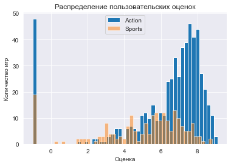

```python
# distribution of user scores
actual_data.query('genre=="Action"')['user_score'].hist(bins=50)
actual_data.query('genre=="Sports"')['user_score'].hist(bins=50, alpha=0.5)
plt.title('Распределение пользовательских оценок')
plt.ylabel('Количество игр')
plt.xlabel('Оценка')
plt.legend(['Action', 'Sports'])
plt.show()
```

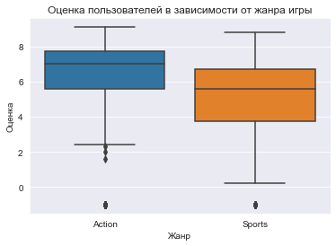

```python
# boxplot for user scores
sns.boxplot(
    data=actual_data.query('genre=="Action" or genre=="Sports"'),
    x='genre',
    y='user_score')

plt.title('Оценка пользователей в зависимости от жанра игры')
plt.xlabel('Жанр')
plt.ylabel('Оценка')
plt.show()
```

Кажется, что в целом пользователи выше оценивают игры жанра "Действие", по сравнению с играми жанра "Спорт". Проведем статистический анализ для проверки этого предположения.

```python
# Student's t-test for two independent samples
alpha = .05

results = st.ttest_ind(
    actual_data.query('genre=="Action" and user_score != -1').dropna()['user_score'],
    actual_data.query('genre=="Sports" and user_score != -1').dropna()['user_score'],
    equal_var=False)

print('p-значение:', results.pvalue)

if results.pvalue < alpha:
    print("Отвергаем нулевую гипотезу")
else:
    print("Не получилось отвергнуть нулевую гипотезу")
```

```
p-значение: 5.858072645452818e-14
Отвергаем нулевую гипотезу
```

**Вывод**: Средние пользовательские рейтинги жанров Action и Sports статистически значимо отличаются. Вероятность получить такие или большие различия случайно чрезвычайно мала, почти нулевая. Таким образом, с помощью графиков и статистического теста можно сказать, что игры жанра "Действие" нравятся пользователям больше, чем игры жанра "Спорт".

## Общий вывод:

Был проведен анализ продаж компьютерных игр с 1980 по 2016 гг в целом и отдельно для трех регионов – Северной Америки, Европы и Японии для установления характеристик игр и закономерностей, по которым можно было бы корректировать продажи и рекламные кампании на следующий год.

При предобработке данных были выявлены и обработаны:

- пропущенные значения в оценках пользователей, критиков и рейтинге. Около 40% игр не имеют данных о рейтинге и оценках одновременно. До 1996 года у всех игр этих данных нет, вероятно, потому что эти показатели не оценивались (так, ESRB была основана в 1994 году). С 2005 года пропущенные значения, вероятно, связаны с другими факторами, возможно, для многих непопулятных игр оценки просто не были выставлены. А возрастная категория могла быть присвоена другой организацией, европейской или японской. Пропущенные значения в рейтинге заменены на “None”. Строки с пропущенными значениями года выпуска игры удалены, так как они составляли менее 2% данных.
- некорректные типы данных. Оценка пользователей переведена в формат float, для этого играм с недостаточным количеством отзывов (“tbd”) присвоено значение «-1». Год выпуска игры переведен в тип integer.

В данных представлены игры на 31 разной платформе, больше всего игр на PS2 и DS. Больше всего игр жанра "Действие" и "Спорт", а вот паззлов меньше всего. Для многих игр продажи небольшие, с другой стороны, некоторые игры продавались десятками миллионов копий. Но в большинстве случаев количество продаж игры не достигало и четверти миллиона. Большинство отзывов критиков сосредоточено между 70 и 80 (из 100), а пользователей - между 7.5 и 8 (из 10).

Количество выпущенных игр и их продаж для периода с 1980 по 2016 гг имеет различную динамику в разные года. Есть периоды резкого роста и спада. Кроме этого, платформы, на которых выпущены игры, имеют свое “время жизни” – около 5 лет. Например, чрезвычайно популярная в 2001-2005 PS2 уже устарела. Для планирования рекламных кампаний и продаж на следующий год важны актуальные данные, не стоит делать ставку на платформы, популярные ранее, но чье "время жизни" подходит к концу. Исходя из динамики продаж игр и динамики выпуска игр, а также "времени жизни" платформ для анализа был выбран лишь актуальный период: с 2012 по 2016 гг, учитывая, что данные за 2016 год неполные.

*Рекомендации по платформам:* В последние годы больше всего продается игр на PS4, популярна также XOne. Высокие продажи PS3 и X360 идут на спад, наверное, не стоит делать ставку на продажу игр на этих платформах.

*Рекомендации по оценкам:* Стоит обратить внимание на игры на платформах с высокими оценками критиков (> 70) – они как правило хорошо продаются, есть положительная связь между продажами и оценкой. А вот оценки пользователей с продажами, вероятно не связаны, что подтверждает и статистический анализ – средние пользовательские оценки на популярной и нет платформах достоверно не отличаются.

*Рекомендации по жанру:* Стабильнее всего продются игры жанра "Shooter", хорошие продажи и у жанра Спорт. Стоит также учесть, что самые большие продажи у отдельных игр и самое большое количество игр - в жанре "Action", кроме того, пользователи оценивают этот жанр выше, что подтверждается статистическим анализом - средние пользовательские рейтинги жанров Action и более покупаемого жанра Sports статистически значимо отличаются. А вот стратегии, паззлы и приключения продаются хуже всего.

*Рекомендации по регионам:* Чтобы корректнее продумать рекламные кампании, следует учитывать особенности региона продаж. В Северной Америке и Европе в топ-5 платформ с лучшими продажами входят в разном порядке одни и те же платформы: PS4,3, X360, XOne, 3DS, но в Америке лидирует Microsoft (X360), а в Европе – Sony (PS3,4). В Японии же X360 и XOne от Microsoft замещают японские PSV и Wii, а лидирует 3DS от Nintendo. Игры жанра Действие очень популярны во всех регионах, но в Японии лидируют ролевые игры, а в Европе и Америке вторые по популярности "стрелялки", в Японии совершенно не популярные. Распределение популярности игр с разным рейтингом ESRB схоже для Северной Америки и Европы. В целом, больше продается игр "Для взрослых". Для Японии картина отличается - больше всего проданных игр не имеют рейтинга ESRB. Тут стоит учесть, что ESRB — это американская организация, она выдаёт рейтинги в Америке, Канаде и Мексике. Вероятно, для того, чтобы корректнее оценить влияние возрастной категории на продажи игр, для каждого региона продаж лучше запрашивать локальный рейтинг.